# Truncated SVD Kmeans on Amazon Fine FOod Reviews

```python
#importing necessary packages
import warnings
warnings.filterwarnings("ignore")
import sqlite3
import pandas as pd
import numpy as np
from sklearn.preprocessing import StandardScaler
import matplotlib.pyplot as plt
import seaborn as sns
import nltk
from sklearn.feature_extraction.text import CountVectorizer,TfidfVectorizer
import pickle
import sklearn.cross_validation
from sklearn.model_selection import train_test_split
from collections import Counter
from sklearn.metrics import accuracy_score
from sklearn import cross_validation
```

## Reading already Cleaned, Preprocessed data from database

After removing stopwords, punctuations, meaningless characters, HTML tags from Text and done stemming. Using it directly as it was alredy done in prevoius assignment

```python
#Reading
conn= sqlite3.connect('cleanedTextData.sqlite')
data= pd.read_sql_query('''
SELECT * FROM Reviews
''',conn)
data=data.drop('index',axis=1)
data.shape
```

```
(364171, 11)
```

```python
data.columns
```

```
Index(['Id', 'ProductId', 'UserId', 'ProfileName', 'HelpfulnessNumerator',
       'HelpfulnessDenominator', 'Score', 'Time', 'Summary', 'Text',
       'CleanedText'],
      dtype='object')
```

```python
data['CleanedText'].head(3)
```

```
0    witti littl book make son laugh loud recit car...
1    rememb see show air televis year ago child sis...
2    beetlejuic well written movi everyth act speci...
Name: CleanedText, dtype: object
```

## Sorting on the basis of 'Time' and taking top 100k pts

This data has time attribute so it will be reasonable to do time based splitting instead of random splitting.

So, before splitting we have to sort our data according to time and here we are taking 100k points from our dataset(population)

```python
data["Time"] = pd.to_datetime(data["Time"], unit = "ms")
data = data.sort_values(by = "Time")
```

```python
#latest 100k points according to time
data= data[:100000]
len(data)
```

```
100000
```

```python
Xdata= data['CleanedText']
```

# SelfDefined Functions

```python
from sklearn.cluster import KMeans
# Using same kmeans function from previous assignment
def optimalKmeans(Xdata):
    '''
    Returns the optimal k by plotting curve on inertia and k with minimal inertia
    '''
    param_K = [2,4,6,8,10,12]
    inertia={}
    for K in param_K:
        model= KMeans(n_clusters=K, init= 'k-means++', precompute_distances= True, n_jobs= -1)
        model.fit(Xdata)
        inertia[K]= model.inertia_
    plt.plot(list(inertia.keys()), list(inertia.values()))
    plt.xlabel("No. of cluster")
    plt.ylabel("Inertia")
    plt.show()
    bestK= min(inertia, key=inertia.get)
    print('The best K according to min inertia is ',bestK)
    return bestK
```

```python
from wordcloud import WordCloud
#prints wordclouds of all clusters seperatly
def wordCloud(clusterPerReview,reviewText,k):
    '''
    Prints  wordclouds of all the clusters given cluster number per review and review text
    '''
    clusterGroup={}
    i=0
    for c in clusterPerReview:
        if c in clusterGroup.keys():
            clusterGroup[c]+= reviewText[i]
        else:
            clusterGroup[c]=reviewText[i]
        i+=1
    print('So we have',k,'clusters here representing in wordcloud:')
    for i in list(set(cluster)):
        print('Cluster Number',i+1,':')
        plt.figure()
        plt.imshow(WordCloud().generate(clusterGroup[i]))
        plt.axis("off")
```

```python
#https://towardsdatascience.com/overview-of-text-similarity-metrics-3397c4601f50
#prints top 20 cosine similar words close to passed word
from sklearn.metrics.pairwise import cosine_similarity
def cosineSimilarWords(word):
    similarity = cosine_similarity(Xsvd)
    word_vect = similarity[FeatureWords.index(word)]
    df= pd.DataFrame({'x':FeatureWords, 'y':word_vect})
    df=df.sort_values(by='y',ascending=0).set_index(np.arange(3000))
    print("Similar Words for",word,':-')
    print(df['x'][1:21])
```

# TFIDF Vectorization

```python
# generating vetor out of text using tfidf only 3000 uses [[idf score]]
tfidfModel=TfidfVectorizer(use_idf=True, max_features=3000 )
XtfidfV= tfidfModel.fit_transform(Xdata)
```

## Building Co-occurrence Matrix

```python
#getting feature names
#taking context window of size five 2 left and 2 right of the word
FeatureWords= tfidfModel.get_feature_names()
#half of context window
NearNeigh = 2
coocMatrix = np.zeros((3000,3000))
for row in list(Xdata.values):
    Sentance = row.split()
    for index,word in enumerate(Sentance):
        if word in FeatureWords:
            #setting left limit not preceed 0
            #settng right limit not exceed end of array
            lvalue= max(index-NearNeigh,0)
            rvalue= min(index+NearNeigh,len(Sentance)-1)
            contextWindow= range(lvalue, rvalue + 1)
            for i in contextWindow:
                if Sentance[i] in FeatureWords:
                    #one is added if word in column found in context window of querry word
                    coocMatrix[FeatureWords.index(word),FeatureWords.index(Sentance[i])] += 1
                else:
                    pass
        else:
            pass
```

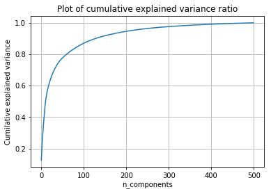

```python
from sklearn.decomposition import TruncatedSVD
svd = TruncatedSVD(n_components = 500)
Xsvd = svd.fit_transform(coocMatrix)
expVar= svd.explained_variance_
cumulativeVariance = np.cumsum(expVar / np.sum(expVar))
plt.plot(cumulativeVariance)
plt.title('Plot of cumulative explained variance ratio')
plt.xlabel('n_components')
plt.ylabel('Cumilative explained variance')
plt.grid()
plt.show()
```

#### Max variance explained around 100 - 150, taking 120 as n_component

```python
#applying SVD on our coocurance matrix
svd = TruncatedSVD(n_components = 120)
Xsvd = svd.fit_transform(coocMatrix)
```

```python
Xsvd.shape
```

```
(3000, 120)
```

# KMeans

Applying Kmeans on the resultant vectors after Truncated SVD

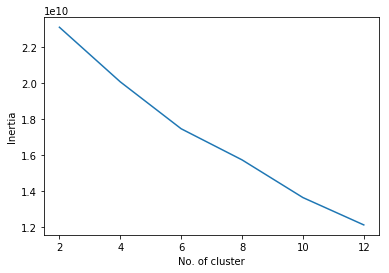

```
The best K according to min inertia is  12
```

```python
k = optimalKmeans(Xsvd)
```